# Project NYC Flights

Author

Jaime Leonardo Corredor Quinche

This Homework Project works with dataframes in the package `nycflights13` about flights, specifically a sample of domestic flights that departed from the three major New York City airports in 2013.

# Data overview

## Package overview

- The data package `nycflights13` package contains five tabular data frames. In total there is information about:
  - 16 **airlines**
  - 1458 **airports**
  - 3322 **planes**
  - 336776 **flights**

The core dataframe `flights` has the following variables:

`year`, `month`, `day`: **Date** of departure.  
`dep_time`, `arr_time`: Actual **departure** and **arrival** times (format HHMM or HMM), local time zone.  
`sched_dep_time`, `sched_arr_time`: **Scheduled departure** and **arrival** times (format HHMM or HMM), local time zone.  
`dep_delay`, `arr_delay`: **Departure** and **arrival delays**, in minutes. Negative times represent early departures/arrivals.  
`carrier`: Two letter **carrier** abbreviation. See `airlines`-dataframe to get the full name.

Basic data visualization

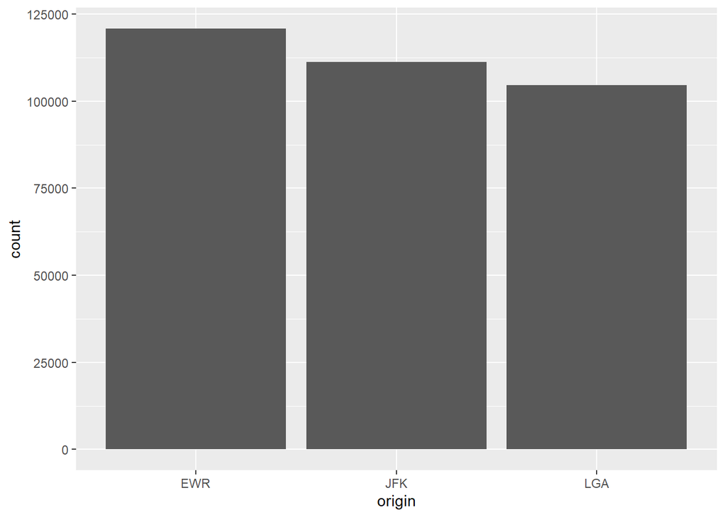

```r
ggplot(data = flights, mapping = aes(x = origin)) +
  geom_bar()
```

In the `flights` dataframe, the `EWR` variable has **120835** rows, the `JFK` has **111279** rows, and the LGA airport has **104662** rows, resulting in a total of **336776** flights

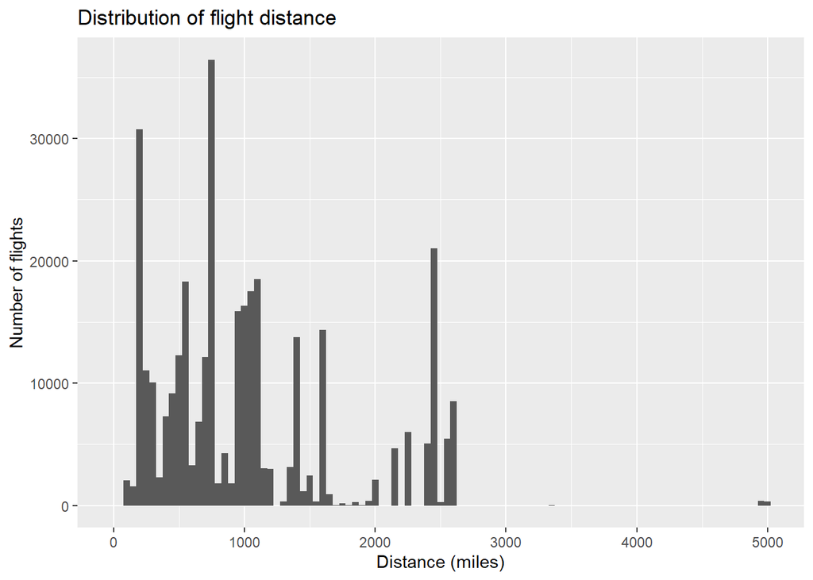

```r
ggplot(data = flights, mapping = aes(x = distance)) + ## It executes origin historiogram
geom_histogram(binwidth = 50) +
labs(title = "Distribution of flight distance", x = "Distance (miles)", y = "Number of flights")
```

### Distribution of flight distance

- Most flights are at **short to medium distances**, mainly below **1,500 miles**. The distribution is **right-skewed**, with a few very long flights.
- Short-haul routes **dominate** the dataset. Long-distance flights are **less frequent** and appear as extreme values.

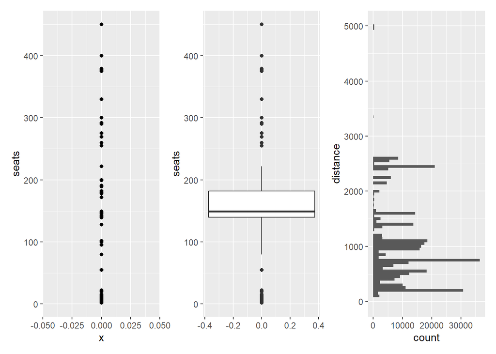

```r
g1 <- ggplot(data = planes, mapping = aes(y = seats, x = 0)) +
  geom_point()
g2 <- ggplot(data = planes, mapping = aes(y = seats)) +
  geom_boxplot()
g3 <- ggplot(data = flights, mapping = aes(y = distance)) +
    geom_histogram(binwidth = 50)# Make your solution into this line
g1 + g2 + g3
```

### Distributions of seats and distance

- Seats are shown with **points** and a **boxplot**, with many values around the middle.
- There are several **outliers**, especially planes with very high seat counts.
- Flight distance shows many **short flights** and fewer long ones.

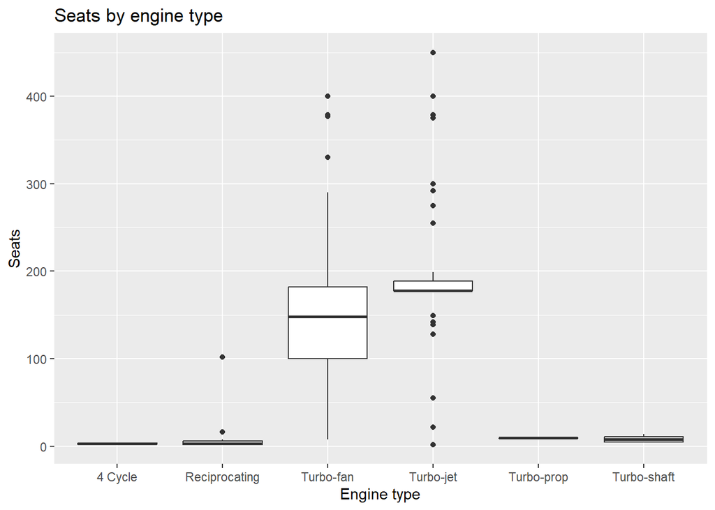

```r
ggplot(data = planes, mapping = aes(x = engine, y = seats)) +    ## Defines boxplot seats by motor tpye
  geom_boxplot() +
    labs(title = "Seats by engine type",
       x = "Engine type",
       y = "Seats")
```

### Seats by engine type

- Turbo-fan and turbo-jet planes have the **highest number of seats**. Large commercial aircraft usually use **turbo-fan or turbo-jet engines**.
- These engine types also show **more variability** and several outliers. Smaller engines are linked to **regional or small planes**.
- Other engines (reciprocating, turbo-prop, turbo-shaft) have **much fewer seats**. Engine type is **strongly related** to aircraft capacity.

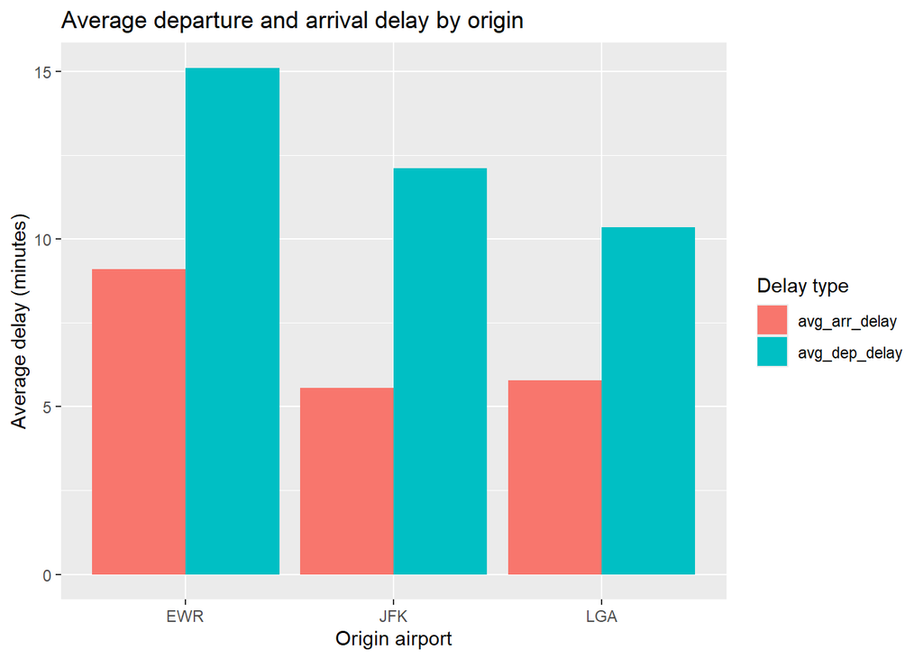

```r
flights |>
  group_by(origin) |>
  summarise(
    avg_dep_delay = mean(dep_delay, na.rm = TRUE),
    avg_arr_delay = mean(arr_delay, na.rm = TRUE)
  ) |>
  pivot_longer(
    cols = c(avg_dep_delay, avg_arr_delay),
    names_to = "delay_type",
    values_to = "minutes"
  ) |>
  ggplot(aes(x = origin, y = minutes, fill = delay_type)) +
  geom_col(position = "dodge") +
  labs(
    title = "Average departure and arrival delay by origin",
    x = "Origin airport",
    y = "Average delay (minutes)",
    fill = "Delay type"
  )
```

### Average departure and arrival delay by origin

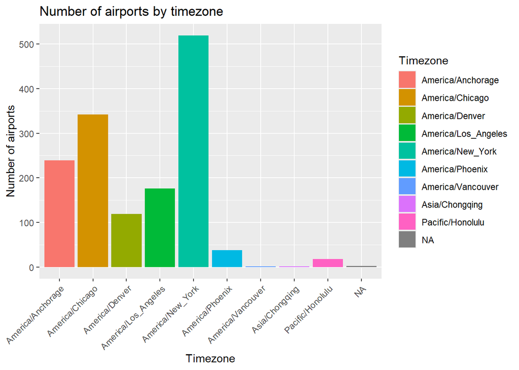

```r
airports |>
  count(tzone) |>
  ggplot(aes(x = tzone, y = n, fill = tzone)) +
  geom_col() +
  labs(
    title = "Number of airports by timezone",
    x = "Timezone",
    y = "Number of airports",
    fill = "Timezone"
  ) +
  theme(axis.text.x = element_text(angle = 45, hjust = 1))
```

### Number of airports by timezone

- America/New_York has the **highest number of airports**, which reflects the high concentration of air traffic in the eastern U.S.
- America/Chicago and America/Los_Angeles also show **large counts**, indicating major aviation hubs in central and western regions.
- Timezones like America/Phoenix, Pacific/Honolulu, and Asia/Chongqing have **very few airports**.
- NA appears with a **small count**, which shows missing or undefined timezone information for some airports.

# Data Wrangling

```r
flights |>
  mutate(speed_kmh = (distance * 1.60934) / (air_time / 60)) |>
  ## Calculates speed: km/h (miles->km and min->h)
  select(air_time, distance, speed_kmh)
```

```
# A tibble: 336,776 × 3
   air_time distance speed_kmh
      <dbl>    <dbl>     <dbl>
 1      227     1400      596.
 2      227     1416      602.
 3      160     1089      657.
 4      183     1576      832.
 5      116      762      634.
 6      150      719      463.
 7      158     1065      651.
 8       53      229      417.
 9      140      944      651.
10      138      733      513.
# ℹ 336,766 more rows
```

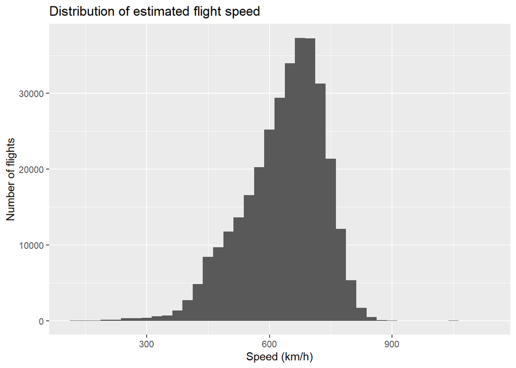

```r
  flights |>
  mutate(speed_kmh = (distance * 1.60934) / (air_time / 60)) |>
   ggplot(mapping = aes(x = speed_kmh)) +
     geom_histogram(binwidth = 25) +
  labs(title = "Distribution of estimated flight speed",
       x = "Speed (km/h)",
       y = "Number of flights")
```

### Distribution of estimated flight speed

- The distribution looks **roughly bell-shaped**, suggesting speed is fairly consistent across flights.

```r
n_arr_120 <- flights |> filter(arr_delay >= 120) |> nrow()
## arr_delay flights > 2 hours

n_houston <- flights |> filter(dest %in% c("IAH", "HOU")) |> nrow()
## Flights to Houston

n_arr_not_dep <- flights |> filter(arr_delay > 120, dep_delay <= 0) |> nrow()
## Arr Delay but not dep Delay

n_dep_hold <- flights |> filter(dep_delay >= 60, arr_delay <= dep_delay - 30) |> nrow()
## Flights with long departure delay and recovered time

cat(
  "Flights with arrival delay ≥ 120 min:", n_arr_120, "\n",
  "Flights to Houston (IAH, HOU):", n_houston, "\n",
  "Flights with large arrival delay but no departure delay:", n_arr_not_dep, "\n",
  "Flights with long departure delay and recovered time:", n_dep_hold
)
```

```
Flights with arrival delay ≥ 120 min: 10200
 Flights to Houston (IAH, HOU): 9313
 Flights with large arrival delay but no departure delay: 29
 Flights with long departure delay and recovered time: 2074
```

- There are **10,200 flights with arrival delays over two hours**, showing that severe delays are not rare.
- A total of **9,313 flights go to Houston**, indicating high traffic to IAH and HOU.
- Only **29 flights arrive very late without departing late**, so delays usually start at departure.
- There are **2,074 flights that recover at least 30 minutes**, meaning airlines can sometimes make up time in the air.

```r
flights |>
summarize(mean_dep_delay = mean(dep_delay, na.rm = TRUE), .by = origin) |> ## Average dep_delay by prigin
arrange(desc(mean_dep_delay)) |> ## Ordering by descending
kable(digits = 2) ## Creating table
```

| origin | mean_dep_delay |
| --- | --- |
| EWR | 15.11 |
| JFK | 12.11 |
| LGA | 10.35 |

- EWR has the **highest average departure delay**, there might be more congestion or operational issues at this airport.

# Data Audit

```r
airports |>
filter(lon > 0) |> ## Filter positive values
select(faa, name, lat, lon, tzone) |>
arrange(desc(lon)) |> ## Order by lenght
kable() ## Tabla para ver los 4 aeropuertos
```

| faa | name | lat | lon | tzone |
| --- | --- | --- | --- | --- |
| SYA | Eareckson As | 52.71227 | 174.11362 | America/Anchorage |
| MYF | Montgomery Field | 32.47590 | 117.75900 | Asia/Chongqing |
| DVT | Deer Valley Municipal Airport | 33.41170 | 112.45700 | Asia/Chongqing |
| EEN | Dillant Hopkins Airport | 72.27083 | 42.89833 | NA |

# More Data Visualization

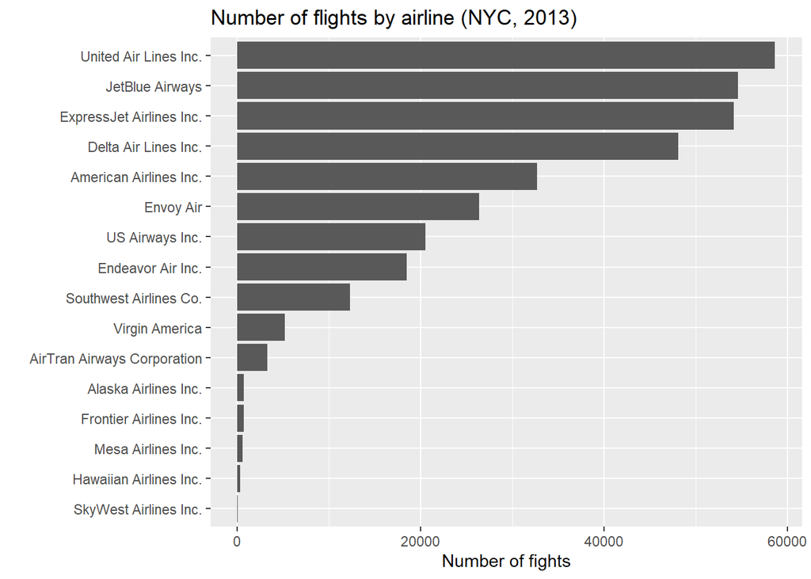

```r
#label: flights-by-airline
flights |>
count(carrier, name = "n_flights") |>                                                        ## counts lfights by cerrer
left_join(airlines, by = join_by(carrier)) |>                                                ## it jpins the data with airlines datas set
mutate(name = fct_reorder(name, n_flights)) |>                                               ## orders by number of flights
ggplot(mapping = aes(x = n_flights, y = name)) +
geom_col() +
labs(title = "Number of flights by airline (NYC, 2013)", x = "Number of fights", y = "")
```

- United Air Lines Inc. has the **highest number of flights**.
- JetBlue Airways and ExpressJet Airlines also have **very high flight counts**.
- American Airlines has **fewer flights than the top four**, suggesting a smaller operational footprint in NYC.

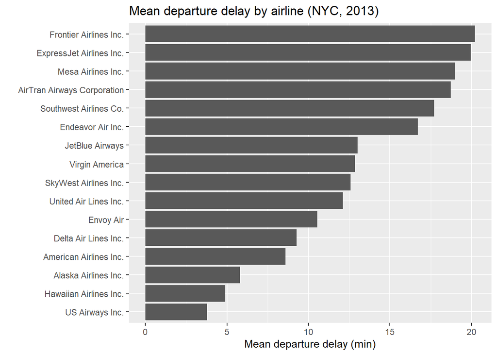

  ```r
  flights |>
  summarize(mean_dep_delay = mean(dep_delay, na.rm = TRUE), .by = carrier) |>
  ## Average dep_delay by carrier
  left_join(airlines, by = join_by(carrier)) |> ## joins by airlines
  mutate(name = fct_reorder(name, mean_dep_delay)) |> ## reorder by average dep_delay
  ggplot(mapping = aes(x = mean_dep_delay, y = name)) +
  geom_col() + ## Barras
  labs(title = "Mean departure delay by airline (NYC, 2013)", x = "Mean departure delay (min)", y = "")
  ```

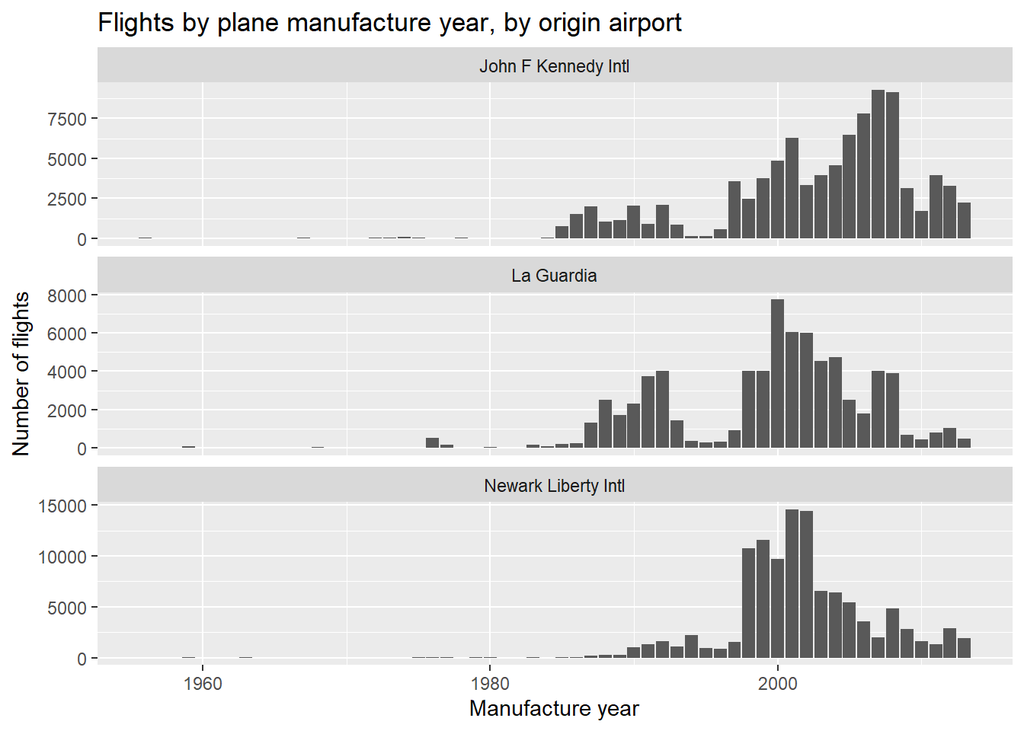

```r
planes_clean <- planes |>
rename(manufacture_year = year) ## avoids conflict with flights$year

flights |>
left_join(planes_clean, by = join_by(tailnum)) |> ## joins flight info  by tailnum
left_join(airports |> select(faa, origin_name = name), by = join_by(origin == faa)) |>
## Ujoins the whole name of the airport
filter(!is.na(manufacture_year)) |> ## filters missing year values
count(origin_name, manufacture_year, name = "n_flights") |> ## counts flights by origin, manufacture year and name
ggplot(mapping = aes(x = manufacture_year, y = n_flights)) +
geom_col() +
facet_wrap(~ origin_name, ncol = 1, scales = "free_y") +
labs(title = "Flights by plane manufacture year, by origin airport",
x = "Manufacture year", y = "Number of flights")
```

- Most flights come from planes manufactured in the **late 1990s to mid-2000s**.
- Newark Liberty Intl shows the **highest flight counts overall**, meaning EWR has maybe the **largest volume** in this dataset.
- JFK has many flights from **newer aircraft (2000s)**.

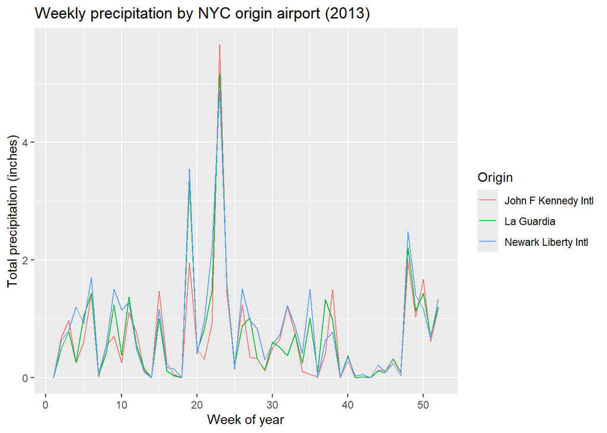

```r
weather |>
mutate(date = as.Date(paste(year, month, day, sep = "-"))) |> ## Creates  YYYY-M-D converts to Date
mutate(week = week(date)) |> ## it takes number of the week
summarize(total_precip = sum(precip, na.rm = TRUE), .by = c(origin, week)) |> ## precipitacion sume by week
left_join(airports |> select(faa, origin_name = name), by = join_by(origin == faa)) |>
## Joins with the whokle airport name
ggplot(mapping = aes(x = week, y = total_precip, color = origin_name)) +
  ## tme serie by week
geom_line() +
labs(title = "Weekly precipitation by NYC origin airport (2013)",
x = "Week of year", y = "Total precipitation (inches)", color = "Origin")
```

- There are a few sharp spikes (around the early 20s and late 40s weeks), which indicates **storm events** that increased total weekly rain a lot.